# Exercise week 4

Shawn Schneidereit

2021-05-07

### 4E3

Using the model definition above, write down the appropriate form of Bayes’ theorem that includes the proper likelihood and priors.

```
Pr(μ, σ|h) = product_i( Normal(hi|μ,σ)Normal(μ0,10)normal(σ|0,1)) /
integral(integral(product_i(Normal(hi|μ, σ)Normal(μ|0,10)normal (σ|0,1)dμdσ)))
```

### 4M1

For the model definition below, simulate observed y values from the prior (not the posterior).

yi ∼ Normal(μ, σ) μ ∼ Normal(0, 10) σ ∼ Exponential(1)

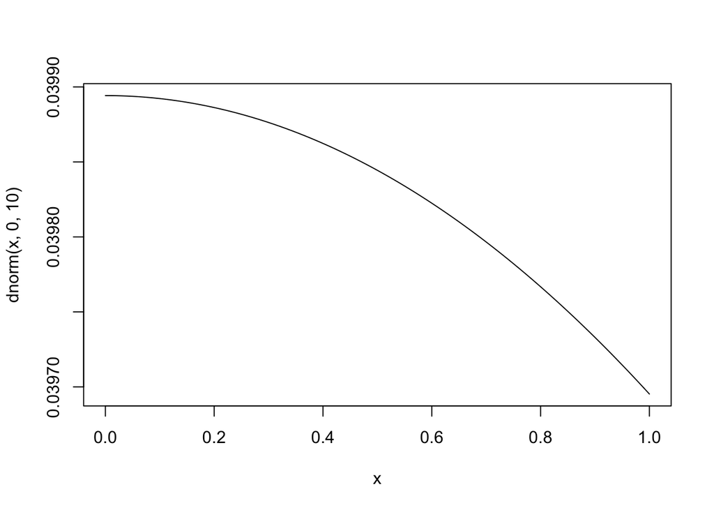

```r
curve( dnorm(x, 0, 10))
```

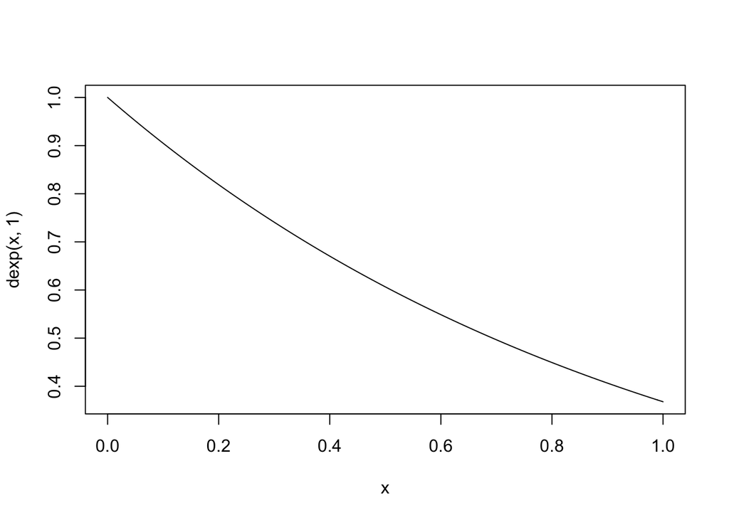

```r
curve(dexp(x, 1))
```

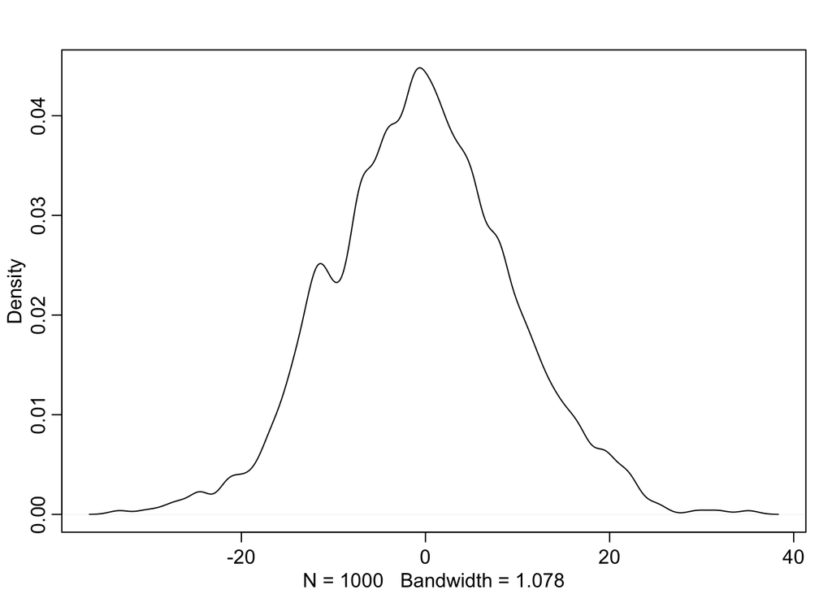

```r
sample_mu <- rnorm( 1000 , 0 , 10 )
sample_sigma <- rexp( 1000 , 1)
prior_h <- rnorm( 1000 , sample_mu , sample_sigma )
dens( prior_h )
```

### 4H2

Select out all the rows in the Howell1 data with ages below 18 years of age. If you do it right, you should end up with a new data frame with 192 rows in it. (a) Fit a linear regression to these data, using brm Present and interpret the estimates. For every 10 units of increase in weight, how much taller does the model predict a child gets?

### A

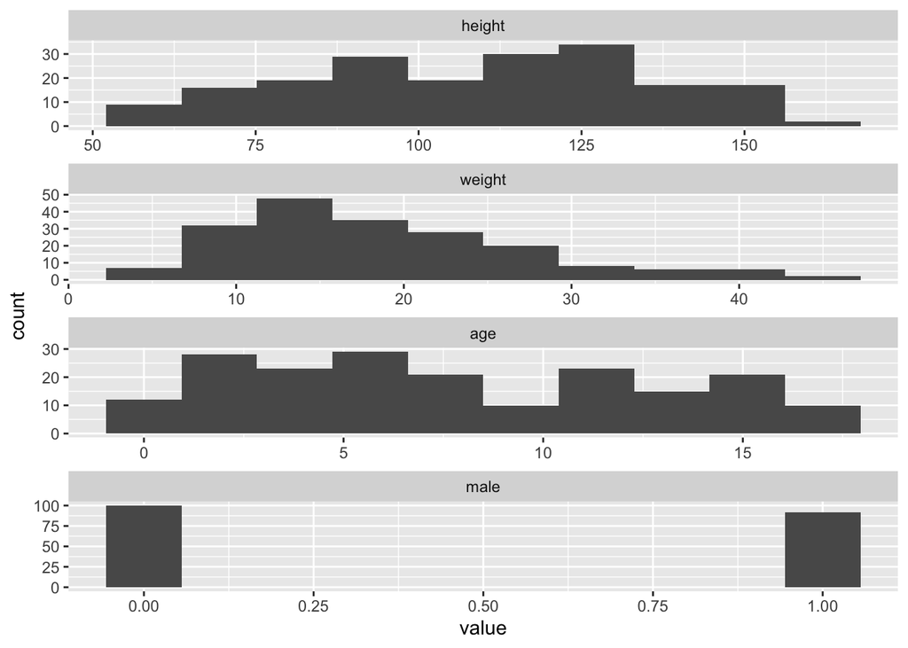

```r
data(Howell1)
d <- Howell1

rm(Howell1)
detach(package:rethinking, unload = T)

d2 <-
  d %>%
  filter(age < 18)

d2 %>%
  pivot_longer(everything()) %>%
  mutate(name = factor(name, levels = c("height", "weight", "age", "male"))) %>%

  ggplot(aes(x = value)) +
  geom_histogram(bins = 10) +
  facet_wrap(~ name, scales = "free", ncol = 1)
```

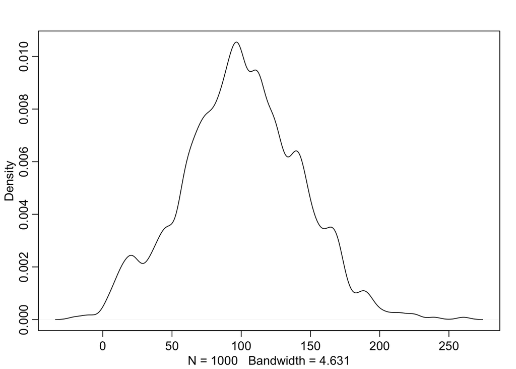

```r
# here is some quick simulation of samples from my priors to validate some prior choices
sample_mu <- rnorm( 1000 , 100 , 40 )
sample_sigma <- runif( 1000 , 0 , 30 )
prior_h <- rnorm( 1000 , sample_mu , sample_sigma )
rethinking::dens( prior_h )
```

```r
b1 <-
  brm(data = d2,
      family = gaussian,
      height ~ 1 + weight,
      prior = c(prior(normal(100, 40), class = Intercept),
                prior(uniform(0, 30), class = sigma)),
      iter = 31000, warmup = 30000, chains = 4, cores = 4,
      seed = 4)
```

```
## Trying to compile a simple C file
```

[output not shown]

```r
summary(b1)
```

```
##  Family: gaussian
##   Links: mu = identity; sigma = identity
## Formula: height ~ 1 + weight
##    Data: d2 (Number of observations: 192)
## Samples: 4 chains, each with iter = 31000; warmup = 30000; thin = 1;
##          total post-warmup samples = 4000
##
## Population-Level Effects:
##           Estimate Est.Error l-95% CI u-95% CI Rhat Bulk_ESS Tail_ESS
## Intercept    58.20      1.39    55.49    60.96 1.00     2728     2442
## weight        2.72      0.07     2.59     2.86 1.00     2537     2155
##
## Family Specific Parameters:
##       Estimate Est.Error l-95% CI u-95% CI Rhat Bulk_ESS Tail_ESS
## sigma     8.54      0.45     7.73     9.49 1.00     3044     2259
##
## Samples were drawn using sampling(NUTS). For each parameter, Bulk_ESS
## and Tail_ESS are effective sample size measures, and Rhat is the potential
## scale reduction factor on split chains (at convergence, Rhat = 1).
```

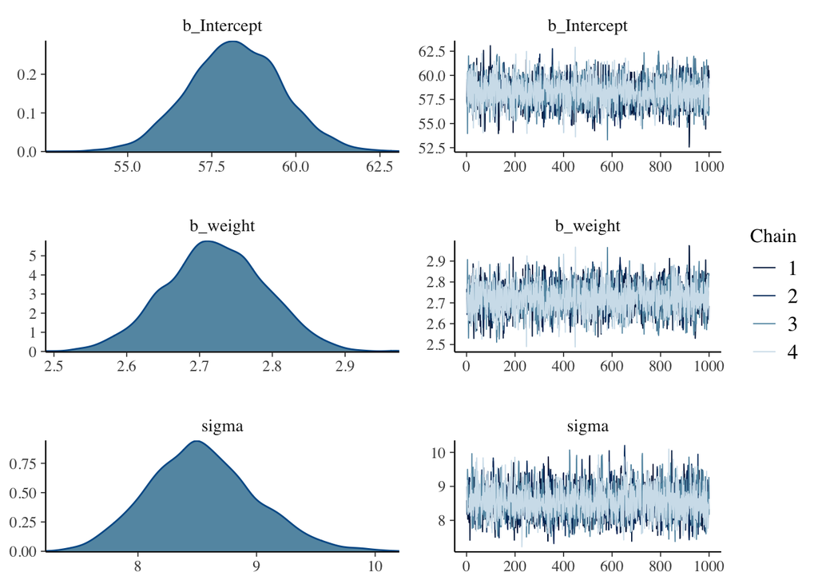

```r
plot(b1)
```

```r
# A quick check of the posteror samples
post <- posterior_samples(b1)
head(post)
```

```
##   b_Intercept b_weight    sigma      lp__
## 1    58.10840 2.765884 8.656483 -688.7832
## 2    57.98397 2.722269 8.661113 -687.9582
## 3    59.30782 2.678108 8.719449 -688.2668
## 4    58.74154 2.663074 8.370137 -688.5705
## 5    57.28643 2.763135 8.034004 -688.5778
## 6    59.59916 2.698769 8.837111 -689.3748
```

```r
post %>%
  pivot_longer(-lp__) %>%
  group_by(name) %>%
  summarise(mean = mean(value),
            sd   = sd(value),
            `2.5%`  = quantile(value, probs = .025),
            `97.5%` = quantile(value, probs = .975)) %>%
  mutate_if(is.numeric, round, digits = 2)
```

```
## # A tibble: 3 x 5
##   name         mean    sd `2.5%` `97.5%`
##   <chr>       <dbl> <dbl>  <dbl>   <dbl>
## 1 b_Intercept 58.2   1.39  55.5    61.0
## 2 b_weight     2.72  0.07   2.59    2.86
## 3 sigma        8.54  0.45   7.73    9.49
```

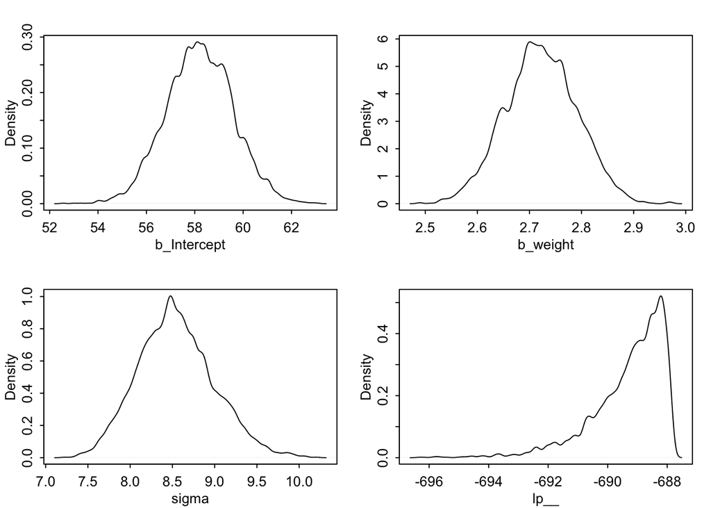

```r
rethinking::dens(post)
```

Our weight estimate is 2.72, meaning that if we increase the weight by 10 kg we would have a 27.2 cm increase in height.

### B

2. Plot the raw data, with height on the vertical axis and weight on the horizontal axis. Super- impose the MAP regression line and 89% interval for the mean. Also superimpose the 89% interval for predicted heights.

```r
weight_seq <-
  tibble(weight = 4:45)

mu <-
  fitted(b1,
         summary = F,
         newdata = weight_seq) %>%
  data.frame() %>%
  # here we name the columns after the `weight` values from which they were computed
  set_names(4:45) %>%
  mutate(iter = 1:n())


mu <-
  mu %>%
  pivot_longer(-iter,
               names_to = "weight",
               values_to = "height") %>%
  # we might reformat `weight` to numerals
  mutate(weight = as.numeric(weight))

head(mu)
```

```
## # A tibble: 6 x 3
##    iter weight height
##   <int>  <dbl>  <dbl>
## 1     1      4   69.2
## 2     1      5   71.9
## 3     1      6   74.7
## 4     1      7   77.5
## 5     1      8   80.2
## 6     1      9   83.0
```

```r
mu_summary <-
  fitted(b1, newdata = weight_seq) %>%
  data.frame() %>%
  bind_cols(weight_seq)

head(mu_summary)
```

```
##   Estimate Est.Error     Q2.5    Q97.5 weight
## 1 69.08684 1.1459655 66.85545 71.34225      4
## 2 71.80911 1.0879595 69.69519 73.93818      5
## 3 74.53138 1.0312756 72.52859 76.53578      6
## 4 77.25365 0.9761443 75.36489 79.15472      7
## 5 79.97592 0.9228437 78.18980 81.76898      8
## 6 82.69819 0.8717098 81.00531 84.40212      9
```

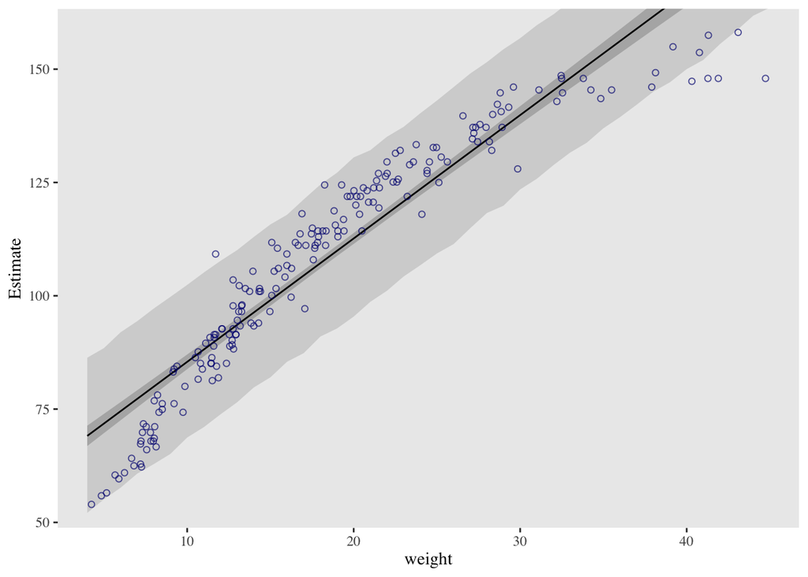

```r
# prediction intervals

pred_height <-
  predict(b1,
          newdata = weight_seq) %>%
  data.frame() %>%
  bind_cols(weight_seq)

d2 %>%
  ggplot(aes(x = weight)) +
  geom_ribbon(data = pred_height,
              aes(ymin = Q2.5, ymax = Q97.5),
              fill = "grey83") +
  geom_smooth(data = mu_summary,
              aes(y = Estimate, ymin = Q2.5, ymax = Q97.5),
              stat = "identity",
              fill = "grey70", color = "black", alpha = 1, size = 1/2) +
  geom_point(aes(y = height),
             color = "navyblue", shape = 1, size = 1.5, alpha = 2/3) +
  coord_cartesian(xlim = range(d2$weight),
                  ylim = range(d2$height)) +
  theme(text = element_text(family = "Times"),
        panel.grid = element_blank())
```

3. What aspects of the model fit concern you? Describe the kinds of assumptions you would change, if any, to improve the model. You don’t have to write any new code. Just explain what the model appears to be doing a bad job of, and what you hypothesize would be a better model.

Some concerns of the model fit I have is that a the lower and particularly upper bounds of the weight distribution the model fit seems to be quite poor. Some assumptions that could be changed to improve overall fit and that the model represents the data better, would be to add a polynomial component to the regression.